# DA Mini Project

- 주제 : 온라인 학습 플랫폼 사용자 행동 패턴 분석
- 개요 : ``` 이번 프로젝트는 학습 서비스를 이용하는 독자들 중 누가 서비스 구독을 연장할지 예측하기 위한 사전 파악에 초점을 맞추고 있습니다. 우리의 목표는 유저들의 학습 습관, 선호도, 이용 행태 등 다양한 측면을 면밀히 분석하는 것입니다.

이를 위해, 우리는 유저들의 학습 패턴, 서비스 이용 시간, 콘텐츠에 대한 반응, 그리고 이들이 얼마나 자주 서비스를 이용하는지 등 다양한 데이터를 수집하고 분석할 계획입니다. 이 데이터는 유저들이 서비스에 얼마나 만족하고 있는지, 어떤 요소들이 그들의 구독 결정에 영향을 미치는지 이해하는 데 중요한 역할을 할 것입니다. ```

- 데이터셋 : mini.csv
  - 메타데이터
    - user_id: 사용자의 고유 식별자
    - subscription_duration: 사용자가 서비스에 가입한 기간 (월)
    - recent_login_time: 사용자가 마지막으로 로그인한 시간 (일)
    - average_login_time: 사용자의 일반적인 로그인 시간
    - average_time_per_learning_session: 각 학습 세션에 소요된 평균 시간 (분)
    - monthly_active_learning_days: 월간 활동적인 학습 일수
    - total_completed_courses: 완료한 총 코스 수
    - recent_learning_achievement: 최근 학습 성취도
    - abandoned_learning_sessions: 중단된 학습 세션 수
    - community_engagement_level: 커뮤니티 참여도
    - preferred_difficulty_level: 선호하는 난이도
    - subscription_type: 구독 유형
    - customer_inquiry_history: 고객 문의 이력
    - payment_pattern : 사용자의 지난 3개월 간의 결제 패턴을 10진수로 표현한 값.
      - 7: 3개월 모두 결제함
      - 6: 첫 2개월은 결제했으나 마지막 달에는 결제하지 않음
      - 5: 첫 달과 마지막 달에 결제함
      - 4: 첫 달에만 결제함
      - 3: 마지막 2개월에 결제함
      - 2: 가운데 달에만 결제함
      - 1: 마지막 달에만 결제함
      - 0: 3개월 동안 결제하지 않음
      - target: 사용자가 다음 달에도 구독을 계속할지 (1) 또는 취소할지 (0)를 나타냄
- 의문점
  - 학습 서비스를 이용하는 독자?  
    → 학습 플랫폼이면 독자보다는 이용자나 수강생이라는 워딩을 쓰지 않나?

```python
import pandas as pd
import numpy as np
import matplotlib.pyplot as plt
import seaborn as sns
import koreanize_matplotlib
import warnings
```

```python
df = pd.read_csv('./data/mini.csv',encoding = 'cp949')

# 경고창 숨기기
warnings.filterwarnings('ignore')
# warnings.filterwarnings('default') 다시 나타내기
```

```python
"""df_ = df.copy()
df_ = df_.iloc[:,1:]
df_['preferred_difficulty_level'] = df_['preferred_difficulty_level'].replace({'Low':0, 'Medium':1, 'High':2})
df_['subscription_type'] = df_['subscription_type'].replace({'Basic':0, 'Premium':1})
#df_.corr()
"""
```

```
"df_ = df.copy() \ndf_ = df_.iloc[:,1:]\ndf_['preferred_difficulty_level'] = df_['preferred_difficulty_level'].replace({'Low':0, 'Medium':1, 'High':2})\ndf_['subscription_type'] = df_['subscription_type'].replace({'Basic':0, 'Premium':1})\n#df_.corr()\n"
```

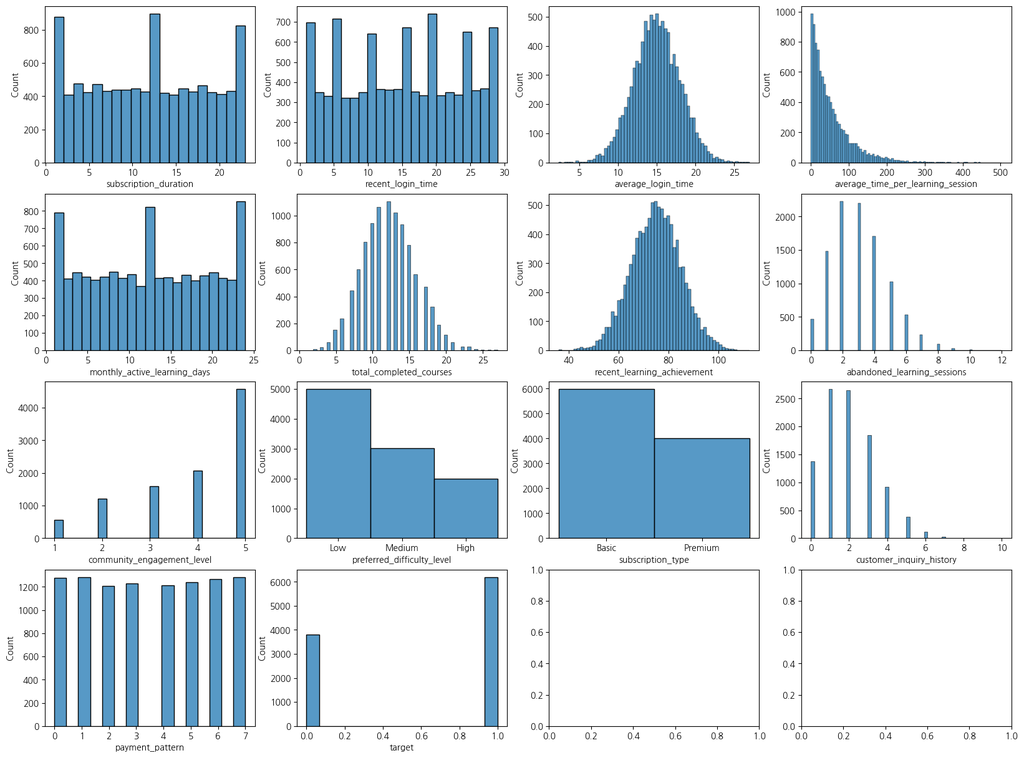

```python
num_col = len(df.columns) - 1

# num_col
fig, axes = plt.subplots(4, 4, figsize=(20, 15))
axes = axes.ravel()

for i in range(num_col):
    axes[i] = sns.histplot(data=df, x=df.columns[i+1], ax=axes[i])
```

# 결제 패턴과 서비스 이용 기간 사이의 관계 알아보기

- payment type : 사용자의 지난 3개월 간의 결제 패턴을 10진수로 표현한 값
- subscription_duration : 사용자가 서비스에 가입한 기간  
  -> 어떤 결제를 말하는 것인가?

## 가설 : 결제 패턴은 월간 구독을 말하는 것이다

### 현재의 payment_type은 보기 불편하므로 바꿔보자

```
payment_type은 지난 3달 간의 결제 내역이므로
- last3 : 첫 달
- last2 : 가운데 달
- last1 : 마지막 달
```

```python
df['last3'] = "" ; df['last2'] = "" ; df['last1'] ="" ;

payment_pattern = [
    [0,0,0], #0
    [0,0,1], #1
    [0,1,0], #2
    [0,1,1], #3
    [1,0,0], #4
    [1,0,1], #5
    [1,1,0], #6
    [1,1,1] #7
]

for pattern in range(0,8):
    mask = (df['payment_pattern']== pattern)
    # category 형태로 만들기 위해서
    df['last3'][mask] = str(payment_pattern[pattern][0])
    df['last2'][mask] = str(payment_pattern[pattern][1])
    df['last1'][mask] = str(payment_pattern[pattern][2])
```

```python
df['payment_type'] = df['last3']+df['last2']+df['last1']
```

[output not shown]

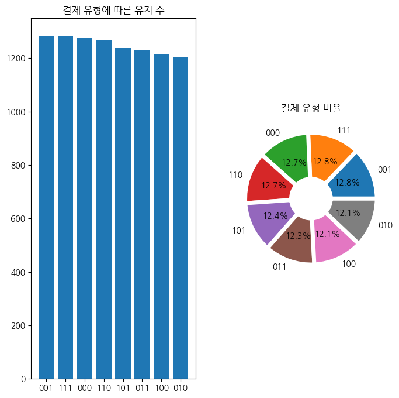

```python
fig, axes = plt.subplots(1,2,figsize= (8,8))
axes = axes.ravel()

axes[0].bar(df['payment_type'].value_counts().index,df['payment_type'].value_counts())
axes[0].set_title('결제 유형에 따른 유저 수')

wedgeprops={'width': 0.7, 'edgecolor': 'w', 'linewidth': 5}
axes[1].pie(df['payment_type'].value_counts(),autopct = '%.1f%%',
        labels = df['payment_type'].value_counts().index,
       wedgeprops = wedgeprops)
axes[1].set_title('결제 유형 비율')

plt.plot()
```

```python
pd.pivot_table(df,
              index = 'subscription_duration',
              columns = 'payment_type',
              values = 'user_id',
              aggfunc = 'count').head()
```

| payment_type subscription_duration | 000 | 001 | 010 | 011 | 100 | 101 | 110 | 111 |
| --- | --- | --- | --- | --- | --- | --- | --- | --- |
| 1 | 55 | 58 | 50 | 47 | 62 | 51 | 60 | 53 |
| 2 | 54 | 59 | 51 | 49 | 67 | 56 | 45 | 62 |
| 3 | 47 | 57 | 61 | 43 | 50 | 52 | 51 | 47 |
| 4 | 67 | 52 | 57 | 55 | 53 | 68 | 67 | 56 |
| 5 | 52 | 57 | 54 | 56 | 54 | 38 | 46 | 67 |

### 가설 : 결제 패턴은 월간 구독을 말하는 것이다 => 기각

**payment type : 사용자의 지난 3개월 간의 결제 패턴을 10진수로 표현한 값**  
**subscription_duration : 사용자가 서비스에 가입한 기간**

- payment가 구독이라면 '111'은 지난 3개월간 구독을 결제한 사람이다. 그렇다면 subscription_duration이 3 미만 일 수 없다  
  ** ('111'인 사람의 subscription_duration은 최소 3이상이어야 한다)

가설 : 결제 패턴은 월간 구독을 말하는 것이다 -> 기각

=> payment와 subscrption은 별개의 개념이다.  
-> 그렇다면 payment가 서비스의 유료 가입, 유료 구독을 의미하지 않을까?

...그래서 데이터를 더 자세히 찾아보니

- target: 사용자가 다음 달에도 구독을 계속할지 (1) 또는 취소할지 (0)를 나타냄  
  -> '사용자가 다음 달에**도**' 이것은 사용자가 특정 달에 구독을 하고 있음을 나타냄  
  (구독을 하지 않는 사람에게 '다음 달에도'라는 표현을 사용하지는 않을 것)  
  **=> 이 데이터는 현재 구독을 하고 있는 사용자들의 데이터**

## 가설 : 결제 패턴은 유료 구독을 말하는 것이다.

=> 구독 유형을 살펴보자

### 구독 유형

```python
df[['subscription_type']].value_counts() # 구독 유형은 basic과 premium 두가지
```

```
subscription_type
Basic                5979
Premium              4021
Name: count, dtype: int64
```

```python
pd.pivot_table(df,
              index = 'subscription_type',
              columns = 'payment_type',
              values = 'user_id',
              aggfunc = 'count')
```

| payment_type subscription_type | 000 | 001 | 010 | 011 | 100 | 101 | 110 | 111 |
| --- | --- | --- | --- | --- | --- | --- | --- | --- |
| Basic | 763 | 722 | 697 | 714 | 764 | 772 | 766 | 781 |
| Premium | 512 | 563 | 509 | 516 | 450 | 466 | 502 | 503 |

### premium 구독이 결제 데이터인가? -> △

- 결제 타입이 000인 (결제를 3달 동안 하지 않은 고객)도 subscription type이 basic과 Premium이 있다  
  => 결제 하지 않아도 premium 구독이 가능하다? 는 결론을 내기에는 이름
1. 3개월보다도 이전에 가입한 구독 유형이 premium일 수도 있음 -> 사용자가 마지막으로 가입한 구독 유형일 수 있음
2. 중간에 basic이나 premium으로 전환했을 수 있으나... 이 데이터에서는 알 수 없음
3. 비로그인...일수도 있으나, 그렇다면 유저 id가 존재하는 것이 의문스러움
4. **결제가 구독이 아닌 서비스에 대한 결제**일 수 있음

=> 일단 구독 유형이 Basic이든 Premium이든 학습할 수 있는 서비스 (학습 플랫폼 이용 가능)

## 가설 : 결제가 사이트의 서비스를 이용하는 것과 관련있다

### monthly_active_learning_days와 결제가 연관이 있나? -> X

- 사이트 접속 횟수 제한이 있는가? -> 없음

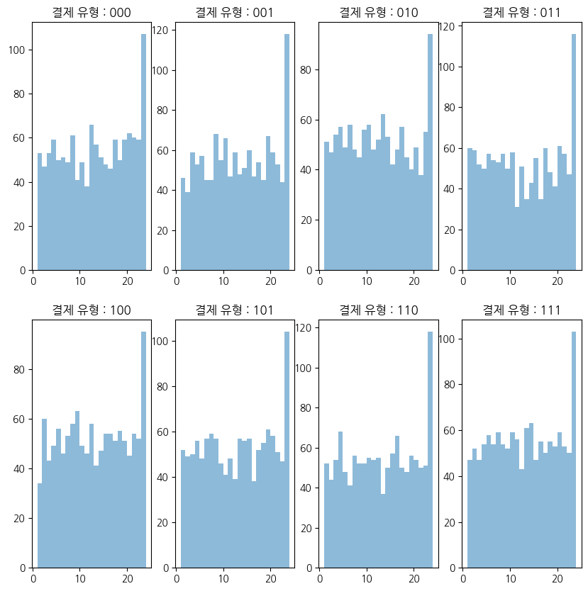

```python
fig, axes = plt.subplots(2,4,figsize= (10,10))
axes = axes.ravel()

i=0
for payment_type, subset in df.groupby('payment_type'):
    axes[i].hist(subset['monthly_active_learning_days'],bins = range(1,25),alpha = 0.5, label = payment_type)
    axes[i].set_title(f"결제 유형 : {payment_type}")
    i += 1
plt.show()
```

### 결제를 안 하면 학습 시간에 제약이 있나? -> X

- 학습 시간에 제약이 있어서, 특정 시간이 지나면 이용할 수 없나? -> X

```python
df['average_time_per_learning_session'].describe()
```

```
count    10000.000000
mean        54.917720
std         56.024310
min          0.011515
25%         15.276611
50%         37.578818
75%         75.584200
max        503.372616
Name: average_time_per_learning_session, dtype: float64
```

```python
cut_bins = np.arange(0,600,40) # 40분 간격으로 학습 시간을 끊기 (중앙값에서 반올림함) 왜 중앙값? -> 8:2법칙 때문에
interval = list(map(lambda x: int(x), np.arange(1,len(cut_bins))))
df['avg_time_interval'] = pd.cut(df['average_time_per_learning_session'],bins = cut_bins,labels = interval)
```

```python
pd.pivot_table(df,
              index = 'avg_time_interval',
              columns = 'payment_type',
              values = 'user_id',
              aggfunc = 'count') #데이터가 깔끔하당...
```

| payment_type avg_time_interval | 000 | 001 | 010 | 011 | 100 | 101 | 110 | 111 |
| --- | --- | --- | --- | --- | --- | --- | --- | --- |
| 1 | 675 | 656 | 614 | 659 | 625 | 656 | 656 | 661 |
| 2 | 322 | 317 | 323 | 278 | 289 | 295 | 324 | 354 |
| 3 | 145 | 151 | 151 | 148 | 144 | 151 | 148 | 130 |
| 4 | 74 | 65 | 55 | 68 | 78 | 73 | 79 | 67 |
| 5 | 31 | 54 | 38 | 33 | 35 | 30 | 32 | 34 |
| 6 | 14 | 21 | 17 | 23 | 25 | 14 | 19 | 18 |
| 7 | 10 | 7 | 4 | 8 | 8 | 8 | 5 | 10 |
| 8 | 1 | 5 | 2 | 9 | 2 | 4 | 4 | 4 |
| 9 | 1 | 2 | 1 | 3 | 5 | 2 | 0 | 2 |
| 10 | 1 | 4 | 0 | 0 | 2 | 1 | 1 | 3 |
| 11 | 1 | 2 | 1 | 1 | 0 | 2 | 0 | 0 |
| 12 | 0 | 1 | 0 | 0 | 0 | 2 | 0 | 0 |
| 13 | 0 | 0 | 0 | 0 | 1 | 0 | 0 | 1 |
| 14 | 0 | 0 | 0 | 0 | 0 | 0 | 0 | 0 |

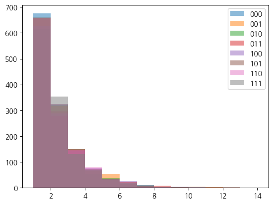

```python
for payment_type, subset in df.groupby('payment_type'):
    plt.hist(subset['avg_time_interval'],bins = range(1,15),alpha = 0.5, label = payment_type)
plt.legend()
plt.show()
```

### 결제를 안 하면 난이도 선택에 제약이 있나? -> X

```python
grouped = df.groupby(['payment_type','preferred_difficulty_level']).size().unstack()
grouped.T
```

| payment_type preferred_difficulty_level | 000 | 001 | 010 | 011 | 100 | 101 | 110 | 111 |
| --- | --- | --- | --- | --- | --- | --- | --- | --- |
| High | 240 | 235 | 250 | 269 | 237 | 241 | 261 | 267 |
| Low | 643 | 679 | 596 | 609 | 624 | 602 | 608 | 631 |
| Medium | 392 | 371 | 360 | 352 | 353 | 395 | 399 | 386 |

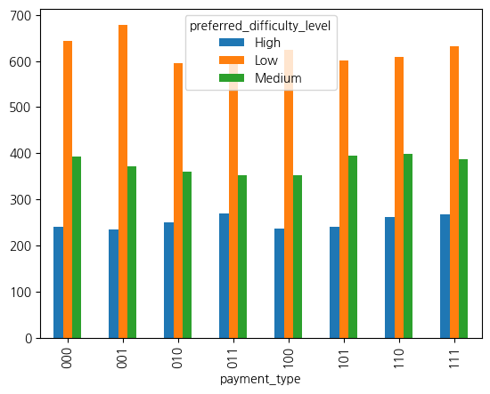

```python
grouped.plot(kind = 'bar',stacked = False)
```

### 선택 가능한 코스의 수에 제약이 있나? -> △

- 코스를 수강하는 것에는 제약이 없어 보이나, 결제에 따라 수강할 수 있는 코스의 수에 제약이 있을 지도 모른다  
  -> 이 데이터에서는 확인 불가

```python
subset = pd.pivot_table(df,
              index = 'total_completed_courses',
              columns = 'payment_type',
              values = 'user_id',
              aggfunc = 'count',
              fill_value = 0)
subset.T
```

| total_completed_courses payment_type | 1 | 2 | 3 | 4 | 5 | 6 | 7 | 8 | 9 | 10 | ... | 18 | 19 | 20 | 21 | 22 | 23 | 24 | 25 | 26 | 27 |
| --- | --- | --- | --- | --- | --- | --- | --- | --- | --- | --- | --- | --- | --- | --- | --- | --- | --- | --- | --- | --- | --- |
| 000 | 0 | 1 | 0 | 6 | 27 | 30 | 39 | 86 | 94 | 148 | ... | 45 | 23 | 14 | 7 | 3 | 6 | 1 | 2 | 0 | 0 |
| 001 | 0 | 2 | 1 | 8 | 20 | 23 | 57 | 78 | 106 | 124 | ... | 46 | 34 | 22 | 5 | 3 | 4 | 2 | 1 | 1 | 0 |
| 010 | 0 | 1 | 4 | 7 | 21 | 31 | 58 | 53 | 104 | 105 | ... | 37 | 20 | 17 | 8 | 4 | 2 | 0 | 0 | 0 | 0 |
| 011 | 0 | 1 | 3 | 10 | 15 | 22 | 55 | 68 | 100 | 102 | ... | 45 | 24 | 10 | 7 | 1 | 4 | 2 | 0 | 1 | 1 |
| 100 | 0 | 1 | 6 | 10 | 18 | 34 | 62 | 66 | 90 | 117 | ... | 42 | 23 | 17 | 3 | 3 | 2 | 0 | 2 | 1 | 1 |
| 101 | 0 | 1 | 3 | 4 | 24 | 37 | 60 | 80 | 100 | 99 | ... | 41 | 24 | 10 | 12 | 5 | 3 | 1 | 0 | 0 | 0 |
| 110 | 0 | 2 | 3 | 7 | 19 | 31 | 52 | 75 | 113 | 126 | ... | 34 | 23 | 17 | 6 | 10 | 4 | 3 | 0 | 2 | 0 |
| 111 | 1 | 1 | 3 | 8 | 11 | 30 | 59 | 93 | 99 | 123 | ... | 36 | 19 | 8 | 14 | 1 | 2 | 3 | 2 | 0 | 1 |

8 rows × 27 columns

[output not shown]

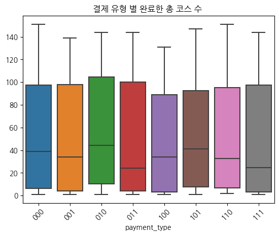

```python
chart = sns.boxplot(pd.pivot_table(df,
              index = 'total_completed_courses',
              columns = 'payment_type',
              values = 'user_id',
              aggfunc = 'count'))
chart.set_xticklabels(chart.get_xticklabels(),rotation = 45)
chart.set_title('결제 유형 별 완료한 총 코스 수 ')
plt.plot()
```

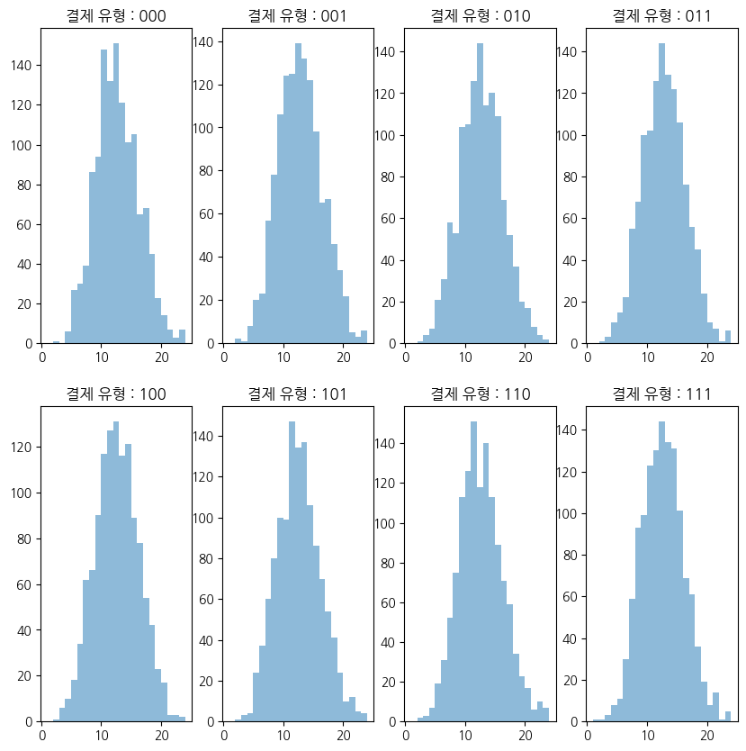

```python
fig, axes = plt.subplots(2,4,figsize= (10,10))
axes = axes.ravel()

i=0
for payment_type, subset in df.groupby('payment_type'):
    axes[i].hist(subset['total_completed_courses'],bins = range(1,25,1),alpha = 0.5, label = payment_type)
    axes[i].set_title(f"결제 유형 : {payment_type}")
    i += 1
plt.show()
```

### 구독 유형에 따라 제한이 있는가?

- 결제 유형에 따른 유의미한 차이를 관찰하지 못했다. 그렇다면 구독 유형에 따라 제한이 있을까? Premium type 사용자들의 커뮤니티 참여도 레벨이 1,2가 존재하지 않는다. 3부터 시작한다.  
  => 왜?  
  사이트에서 커뮤니티 참여 레벨을 측정할 때, premium 구독을 한다면 이점을 주는 걸 수도?

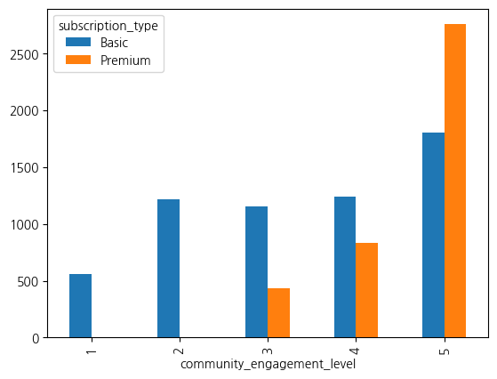

```python
pd.pivot_table(df,
              index = 'community_engagement_level',
              columns = 'subscription_type',
              values = 'user_id',
              aggfunc = 'count').plot(kind='bar',stacked=False)
plt.show()
```

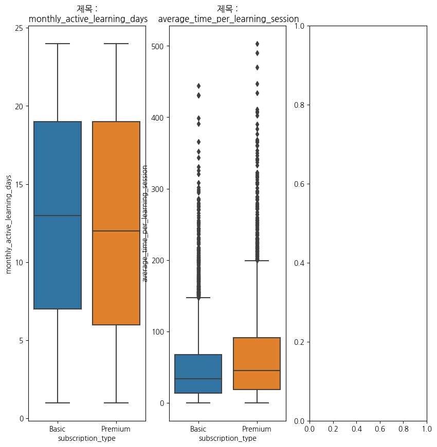

```python
fig, axes = plt.subplots(1,3,figsize= (10,10))
axes = axes.ravel()

i=0
data_list = ['monthly_active_learning_days', 'average_time_per_learning_session','total_completed_courses']
for types, subset in df.groupby('subscription_type'):
    sns.boxplot(x = 'subscription_type',y = data_list[i],ax=axes[i],data = df)
    axes[i].set_title(f"제목 :\n {data_list[i]}")
    i += 1
plt.show()
```

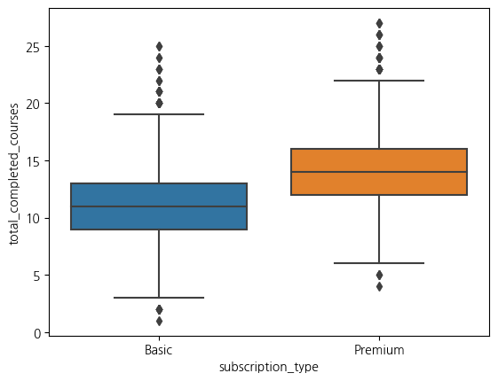

```python
sns.boxplot(x = df['subscription_type'],y = df[data_list[i]])
```

- premium 유저는 커뮤니티 레벨 참여도가 3,4,5만 존재한다.
- monthly active learning days는 premium이 살짝 작다.
- 각 학습 세션에 소요된 평균 시간는 premium이 조금 더 길다,
- 완료한 총 코스 수는 premium의 사용자가 더 많다.

-> premium은 사이트에 잘 들어오지 못하는 사람들을 위한 것일까?  
-> premium의 학습 세션이 더 길게 나타나는 것은 premium을 위한 서비스가 존재하는 것이 아닐까?

## 결과 :

1. 구독과 결제를 별개인 학습 플랫폼이다.
2. 결제를 하지 않는다 해서 서비스를 이용하는 데 제약이 있는 플랫폼은 아니다. 이는 구독 유형에도 해당된다. 난이도 선택, 커뮤니티 이용, 이용 시간 제약 등의 제약은 존재하지 않음  
   => 하지만 premium 유저들의 커뮤니티 이용 레벨이 높은 것으로 봐서, premium을 이용하면 어떠한 메리트가 있을 것이라 추측 가능

## 가정

1. 결제를 한다면 어떠한 디메리트가 없애주거나, 메리트가 있을 가능성이 있음 (예시로 유튜브처럼 구독은 무료로 하며 댓글 달기, 좋아요, 커뮤니티 이용은 자유로우나, 결제를 하면 이용가능한 프리미엄이 있을 수 있음)
2. 결제라는 것이 구독이 아닌 어떠한 콘텐츠를 결제하는 것일 가능성이 있음
3. target다음 달에도 구독을 계속할 사용자... 이건 구독을 연장한다고 볼 수 있는데, 구독을 하지 않는 사람에게 구독을 연장한다는 표현을 사용하지는 않을 것  
   => 이건 구독을 한 사용자들만을 수집한 데이터  
   -> 학습 플랫폼 사이트 안의, 특정한 서비스에서 가져온 데이터일 듯

# 사용자의 로그인 시간과 학습 시간

```python
df[['average_login_time','average_time_per_learning_session']].describe()
```

|  | average_login_time | average_time_per_learning_session |
| --- | --- | --- |
| count | 10000.000000 | 10000.000000 |
| mean | 14.994076 | 54.917720 |
| std | 3.001869 | 56.024310 |
| min | 2.366189 | 0.011515 |
| 25% | 13.025597 | 15.276611 |
| 50% | 14.979228 | 37.578818 |
| 75% | 16.995340 | 75.584200 |
| max | 26.998490 | 503.372616 |

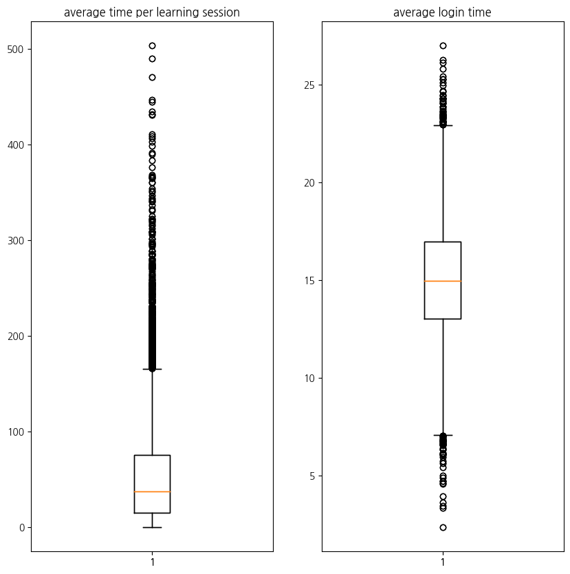

```python
fig, axes = plt.subplots(1,2,figsize= (10,10))
axes = axes.ravel()

axes[0].boxplot(df['average_time_per_learning_session'])
axes[0].set_title('average time per learning session')
axes[1].boxplot(df['average_login_time'])
axes[1].set_title('average login time')

box1 = axes[0].boxplot(df['average_time_per_learning_session'])
box2 = axes[1].boxplot(df['average_login_time'])
```

```python
#box1 = axes[0].boxplot(df['average_time_per_learning_session'])
#box2 = axes[1].boxplot(df['average_login_time'])

fliers1 = [item.get_ydata() for item in box1['fliers']]
fliers2 = [item.get_ydata() for item in box2['fliers']]

print(f'average time per learning session의 이상치 개수 : {len(fliers1[0])}')
print(f'login time의 이상치 개수 : {len(fliers2[0])}')
```

```
average time per learning session의 이상치 개수 : 512
login time의 이상치 개수 : 90
```

```python
whiskers_learn = [item.get_ydata() for item in box1['whiskers']]
print(whiskers_learn)
# max = 165.42
```

```
[array([1.52766113e+01, 1.15147969e-02]), array([ 75.5842005 , 165.42079575])]
```

```python
whiskers_login = [item.get_ydata() for item in box2['whiskers']]
print(whiskers_login)
# max = 22.92
```

```
[array([13.02559703,  7.09570601]), array([16.99534047, 22.92332603])]
```

### boxplot이 두 데이터 모두에 이상치가 있다고 하나, 조치 하지 않는다

=> 전자의 learning session은 대략 512명의 데이터가 이상치라 하나, 학습 시간이 길다는 것은 학습을 몰아서 하는 편이라 추측 가능함  
=> 후자의 login time은 로그인 하자마자 학습으로 바로 넘어갈 수도 있으며, 로그인 후 잠시 자리를 비울 가능성이 있고 / 로그인 시간이 긴 것은 이벤트나 커뮤니티 등의 활동을 할 수 있음

- 사용자의 로그인 시간이 학습 시간에 포함되어 있지 않다 -> 로그인과 학습을 별도로 취급함.
- 로그인한 사람이 학습을 듣지 않는다면 무엇을 할까?  
  -> 로그인 시간이 짧으면 -> 바로 학습으로 넘어갈 수 있을 것이고  
  -> 로그인 시간이 길다 -> 콘텐츠 탐색, 커뮤니티, 이벤트 참여 등등...의 활동이 있을 수도 있음

## 로그인 시간이 긴 사람들이 커뮤니티 참여도가 높을 것이다?

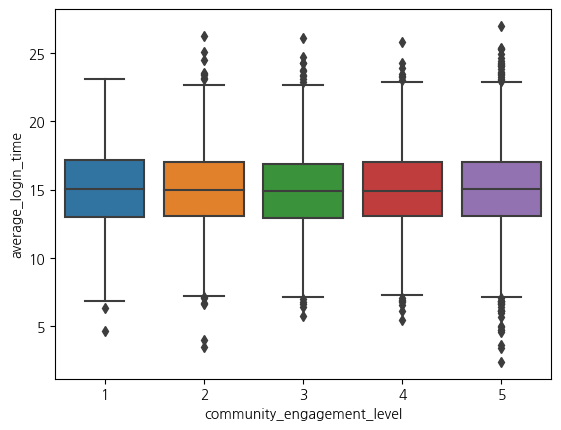

```python
sns.boxplot(x = df['community_engagement_level'],
           y = df['average_login_time'])
```

```python
grouped = df.groupby('community_engagement_level')['average_login_time']
for name, group in grouped:
    q1 = group.quantile(0.25)
    q3 = group.quantile(0.75)
    iqr = q3 - q1 # 제 3분위 수 - 제 1 분위 수
    lower_bound = q1 - 1.5 * iqr
    upper_bound = q3 + 1.5 * iqr
    outliers = group[(group < lower_bound) | (group > upper_bound)]
    upper_outliers = group[(group > upper_bound)]
    lower_outliers = group[(group < lower_bound)]
    print(f"커뮤티니 참여도 {name}의 이상치 개수 : {len(outliers)}")  # 이상치 : {list(outliers)}")
    print(f"커뮤티니 참여도 {name}의 upper_bound 이상의 이상치 개수 : {len(upper_outliers)}")
    print(f"커뮤티니 참여도 {name}의 lower_bound 아래의 이상치 개수 : {len(lower_outliers)}")
    print('')
```

```
커뮤티니 참여도 1의 이상치 개수 : 2
커뮤티니 참여도 1의 upper_bound 이상의 이상치 개수 : 0
커뮤티니 참여도 1의 lower_bound 아래의 이상치 개수 : 2

커뮤티니 참여도 2의 이상치 개수 : 14
커뮤티니 참여도 2의 upper_bound 이상의 이상치 개수 : 8
커뮤티니 참여도 2의 lower_bound 아래의 이상치 개수 : 6

커뮤티니 참여도 3의 이상치 개수 : 15
커뮤티니 참여도 3의 upper_bound 이상의 이상치 개수 : 10
커뮤티니 참여도 3의 lower_bound 아래의 이상치 개수 : 5

커뮤티니 참여도 4의 이상치 개수 : 14
커뮤티니 참여도 4의 upper_bound 이상의 이상치 개수 : 7
커뮤티니 참여도 4의 lower_bound 아래의 이상치 개수 : 7

커뮤티니 참여도 5의 이상치 개수 : 45
커뮤티니 참여도 5의 upper_bound 이상의 이상치 개수 : 22
커뮤티니 참여도 5의 lower_bound 아래의 이상치 개수 : 23
```

```python
df.groupby('community_engagement_level').size().T
```

```
community_engagement_level
1     559
2    1219
3    1588
4    2070
5    4564
dtype: int64
```

```python
df['average_login_time'] = round(df['average_login_time'])
df['average_login_time'] = df['average_login_time'].astype(int)
```

```python
grouped = pd.pivot_table(df,
               index = 'average_login_time',
               columns = 'community_engagement_level',
               values = 'user_id',
               aggfunc = 'count',
               fill_value=0
              )
grouped.T
```

| average_login_time community_engagement_level | 2 | 3 | 4 | 5 | 6 | 7 | 8 | 9 | 10 | 11 | ... | 18 | 19 | 20 | 21 | 22 | 23 | 24 | 25 | 26 | 27 |
| --- | --- | --- | --- | --- | --- | --- | --- | --- | --- | --- | --- | --- | --- | --- | --- | --- | --- | --- | --- | --- | --- |
| 1 | 0 | 0 | 0 | 1 | 1 | 2 | 4 | 11 | 24 | 31 | ... | 51 | 28 | 17 | 10 | 5 | 3 | 0 | 0 | 0 | 0 |
| 2 | 0 | 1 | 1 | 0 | 0 | 8 | 8 | 14 | 44 | 68 | ... | 96 | 60 | 48 | 21 | 13 | 4 | 3 | 1 | 1 | 0 |
| 3 | 0 | 0 | 0 | 0 | 2 | 5 | 18 | 31 | 47 | 84 | ... | 111 | 98 | 55 | 24 | 15 | 8 | 4 | 1 | 1 | 0 |
| 4 | 0 | 0 | 0 | 1 | 1 | 11 | 18 | 29 | 63 | 122 | ... | 164 | 124 | 79 | 40 | 9 | 9 | 2 | 0 | 1 | 0 |
| 5 | 1 | 1 | 1 | 5 | 7 | 21 | 38 | 90 | 164 | 217 | ... | 382 | 234 | 145 | 94 | 33 | 17 | 9 | 5 | 0 | 1 |

5 rows × 26 columns

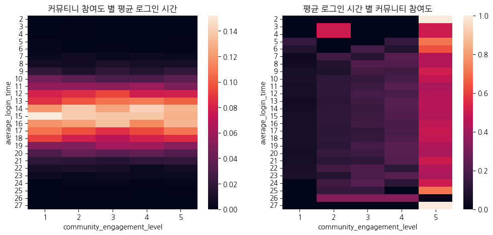

```python
fig, axes = plt.subplots(1,2,figsize= (12,5))
axes = axes.ravel()

result = grouped.div(grouped.sum()) # 값을 해당 값의 sum(community_engagement_level)로 나눈 값
sns.heatmap(result,ax = axes[0])
axes[0].set_title('커뮤티니 참여도 별 평균 로그인 시간') # sns.heatmap을 기준으로 세로 방향으로 더하면 1
# 커뮤티니 참여도는 다르나, 평균 로그인 시간이 보이는 경향은 비슷하다.


sns.heatmap(grouped.div(grouped.sum(axis=1),axis=0)) # 값을 해당 값의 sum(average_login_time)로 나눈 값
axes[1].set_title('평균 로그인 시간 별 커뮤니티 참여도') # sns.heatmap을 기준으로 가로 방향으로 더하면 1
plt.show()
# # 로그인 시간이 짧아도, 커뮤니티 참여도가 높은 사람들이 많다.
# => 로그인 시간이 길면, 커뮤니티 참여도가 낮을 것이다 라고 가정한 것은... 틀리다고 말하기엔 이르다.
#=> 해당 사이트의 커뮤니티 참여도의 기준을 모르기 때문에
```

```python
# 로그인 시간이 1분 늘어날 수록, 레벨의 증감율?
grouped2 = grouped[grouped > 0].dropna() # 0으로는 나눗셈이 되지 않으니 행에 0이 있다면 자른다
grouped2
```

| community_engagement_level average_login_time | 1 | 2 | 3 | 4 | 5 |
| --- | --- | --- | --- | --- | --- |
| 7 | 2.0 | 8.0 | 5.0 | 11.0 | 21.0 |
| 8 | 4.0 | 8.0 | 18.0 | 18.0 | 38.0 |
| 9 | 11.0 | 14.0 | 31.0 | 29.0 | 90.0 |
| 10 | 24.0 | 44.0 | 47.0 | 63.0 | 164.0 |
| 11 | 31.0 | 68.0 | 84.0 | 122.0 | 217.0 |
| 12 | 45.0 | 103.0 | 148.0 | 161.0 | 362.0 |
| 13 | 48.0 | 119.0 | 170.0 | 227.0 | 464.0 |
| 14 | 67.0 | 169.0 | 198.0 | 293.0 | 594.0 |
| 15 | 85.0 | 170.0 | 217.0 | 283.0 | 588.0 |
| 16 | 66.0 | 150.0 | 215.0 | 238.0 | 599.0 |
| 17 | 60.0 | 117.0 | 136.0 | 195.0 | 492.0 |
| 18 | 51.0 | 96.0 | 111.0 | 164.0 | 382.0 |
| 19 | 28.0 | 60.0 | 98.0 | 124.0 | 234.0 |
| 20 | 17.0 | 48.0 | 55.0 | 79.0 | 145.0 |
| 21 | 10.0 | 21.0 | 24.0 | 40.0 | 94.0 |
| 22 | 5.0 | 13.0 | 15.0 | 9.0 | 33.0 |
| 23 | 3.0 | 4.0 | 8.0 | 9.0 | 17.0 |

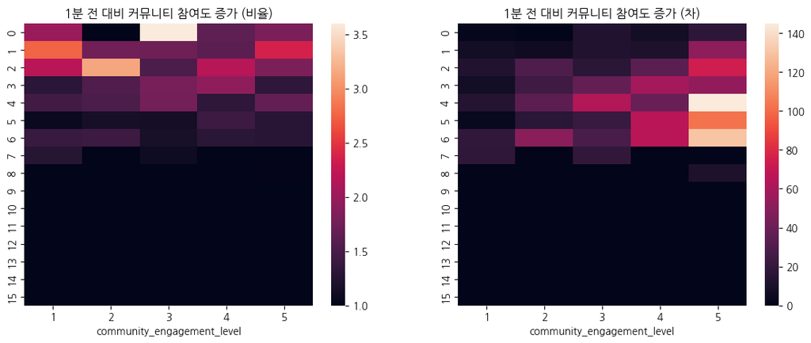

```python
fig, axes = plt.subplots(1,2,figsize= (14,5))
axes = axes.ravel()

grouped3 = []
for i in range(1,len(grouped2)):
    grouped3.append(
        grouped2.iloc[i,:] /grouped2.iloc[i-1,:] #이전 로그인 시간 대비 비율
                   )
grouped3 = pd.DataFrame(grouped3)
sns.heatmap(grouped3 , vmin = 1, ax = axes[0]) # 비율이 1 아래 (이전보다 감소하면 표시하지 않는다)
axes[0].set_title('1분 전 대비 커뮤니티 참여도 증가 (비율)')


grouped3 = []
for i in range(1,len(grouped2)):
    grouped3.append(
        grouped2.iloc[i,:] -grouped2.iloc[i-1,:]#이전 로그인 시간 대비 차
                   )
grouped3 = pd.DataFrame(grouped3)
sns.heatmap(grouped3 , vmin = 0,ax = axes[1]) # 차가 0 이하 (이전보다 감소하면 표시하지 않는다)
axes[1].set_title('1분 전 대비 커뮤니티 참여도 증가 (차)')
plt.show()

# 주의할 점 여기서 0은 7분에서 8분으로 증가했을 때의 차이!
```

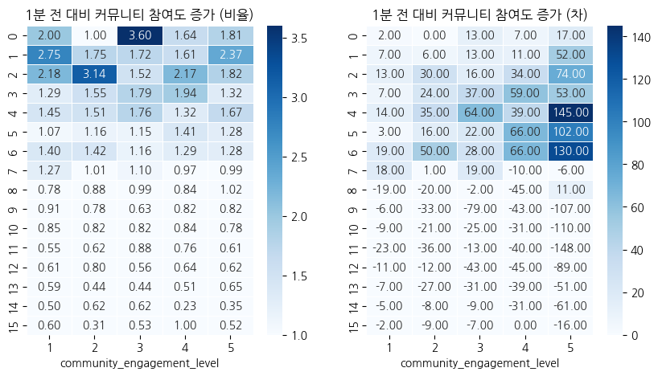

```python
fig, axes = plt.subplots(1,2,figsize= (10,5))
axes = axes.ravel()

grouped3 = []
for i in range(1,len(grouped2)):
    grouped3.append(
        grouped2.iloc[i,:] /grouped2.iloc[i-1,:] #이전 로그인 시간 대비 비율
                   )
grouped3 = pd.DataFrame(grouped3)
sns.heatmap(grouped3 , vmin = 1, ax = axes[0],
            annot=True, fmt = '.2f', linewidths=.5, cmap='Blues'

           ) # 비율이 1 아래 (이전보다 감소하면 표시하지 않는다)
axes[0].set_title('1분 전 대비 커뮤니티 참여도 증가 (비율)')


grouped3 = []
for i in range(1,len(grouped2)):
    grouped3.append(
        grouped2.iloc[i,:] -grouped2.iloc[i-1,:]#이전 로그인 시간 대비 차
                   )
grouped3 = pd.DataFrame(grouped3)
sns.heatmap(grouped3 , vmin = 0,ax = axes[1],
           annot=True,
fmt = '.2f', linewidths=.5, cmap='Blues') # 차가 0 이하 (이전보다 감소하면 표시하지 않는다)
axes[1].set_title('1분 전 대비 커뮤니티 참여도 증가 (차)')
plt.show()

# 주의할 점 여기서 0은 7분에서 8분으로 증가했을 때의 차이!
```

```python
"""fig, axes = plt.subplots(1,2,figsize= (10,5))
axes = axes.ravel()

sns.heatmap(grouped3 , vmin = 0,ax = axes[0])
axes[1].text(0.5,0.5,'레벨이 높을 수록 증가하는 수치는 큰 편')
axes[1].xaxis.set_visible(False)
axes[1].yaxis.set_visible(False)
#axes[1].rcParams["figure.figsize"] = (3,5)"""
```

```
'fig, axes = plt.subplots(1,2,figsize= (10,5))\naxes = axes.ravel()\n\nsns.heatmap(grouped3 , vmin = 0,ax = axes[0])\naxes[1].text(0.5,0.5,\'레벨이 높을 수록 증가하는 수치는 큰 편\')\naxes[1].xaxis.set_visible(False)\naxes[1].yaxis.set_visible(False)\n#axes[1].rcParams["figure.figsize"] = (3,5)'
```

### 로그인 시간이 긴 사람들이 커뮤니티 참여도가 높을 것이다?

1. 커뮤니티 참여도가 5인 사람들에게서 높은 이상치가 좀 더 관찰이 되긴 함. 하지만 평균은 유사하게 관찰됌
2. 비율로 살펴본 결과, 커뮤티니 참여도가 높아도 평균 로그인 시간이 높게 나타나지는 않는다. .
3. 로그인 시간이 짧아도, 커뮤니티 참여도가 높은 사람들이 많다.
4. 로그인 시간이 길면, 커뮤니티 참여도가 낮을 것이다 라고 가정한 것은... 틀리다고 말하기엔 이르다.  
   => 해당 사이트의 커뮤니티 참여도의 기준을 모르기 때문에
5. 레벨이 2일때, 로그인 시간 2-4와 레벨이 2-4일 때 로그인 시간 26에서 나타나는 것은 이상치에서 비롯된 것이다. (로그인 시간이 매우 짧거나, 또는 매우 긴 때로 저 때의 접속자는 1~3명에 불과함)
6. 커뮤니티 레벨이 올라갈수록 1분 전 대비 참여도가 증가하는 정도가 크다 (7분~14분 까지 1분 대비로)

## 로그인 시간이 긴 사람들이 구독 연장률이 높을 것이다?

↓

# 서비스 구독 예정자와 아닌 사람의 차이

```python
df['target'][df['target']==1] = '구독 연장 예정'
df['target'][df['target']==0] = '구독 취소 예정'
```

[output not shown]

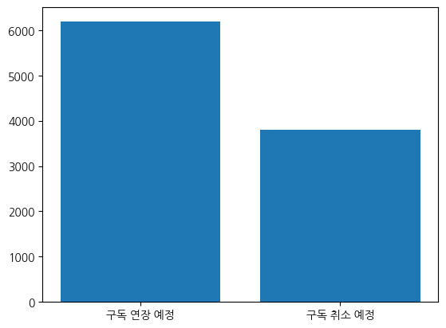

```python
plt.bar(df['target'].value_counts().index, df['target'].value_counts(),label = ['0','1'])
```

## 구독을 연장하는 사람들은, 구독 취소 예정인 사람들과 비교했을 때, 상대적으로 활동적이지 않을까?

### 가설 : 커뮤티니 참여도가 높으면 구독 연장 비율이 높을 것이다

```python
grouped = df.groupby(['target','community_engagement_level']).size().unstack()
grouped
```

| community_engagement_level target | 1 | 2 | 3 | 4 | 5 |
| --- | --- | --- | --- | --- | --- |
| 구독 연장 예정 | 348 | 751 | 968 | 1265 | 2867 |
| 구독 취소 예정 | 211 | 468 | 620 | 805 | 1697 |

[figure not shown]

```python
dffd = pd.DataFrame(grouped.iloc[0,:] /grouped.iloc[1,:],)
dffd.plot(kind='line')
plt.ylim(1,2)
plt.xticks([1,2,3,4,5])
plt.title('커뮤티니 참여도에 따른 (구독 연장 / 구독 취소) 비율')
# 커뮤티니 참여도에 따라 구독 연장이 늘어나지는 않음
```

### 가설 : 커뮤티니 참여도가 높으면 구독 연장 비율이 높을 것이다 -> X

커뮤티니 참여도가 높아져도, 비율은 상승하지 않음

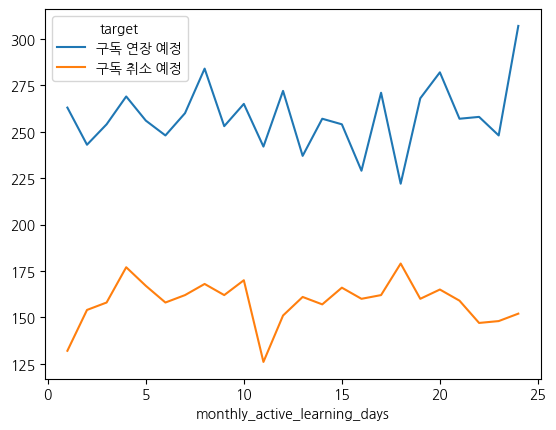

```python
grouped = pd.pivot_table(df,
              index = 'monthly_active_learning_days',
              columns = 'target',
              values = 'user_id',
              aggfunc = 'count')
grouped.plot(kind = 'line')  #monthly active learning days가 많아 진다고, 구독 연장이 많이 이루어지지는 않는다
# 왜냐하면 monthly active learning days가 낮을 때도, 구독 연장 예정은 구독 취소 예정에 비해
```

```python
grouped = pd.pivot_table(df,
              index = 'monthly_active_learning_days',
              columns = 'target',
              values = 'user_id',
              aggfunc = 'count')
grouped.T
```

| monthly_active_learning_days target | 1 | 2 | 3 | 4 | 5 | 6 | 7 | 8 | 9 | 10 | ... | 15 | 16 | 17 | 18 | 19 | 20 | 21 | 22 | 23 | 24 |
| --- | --- | --- | --- | --- | --- | --- | --- | --- | --- | --- | --- | --- | --- | --- | --- | --- | --- | --- | --- | --- | --- |
| 구독 연장 예정 | 263 | 243 | 254 | 269 | 256 | 248 | 260 | 284 | 253 | 265 | ... | 254 | 229 | 271 | 222 | 268 | 282 | 257 | 258 | 248 | 307 |
| 구독 취소 예정 | 132 | 154 | 158 | 177 | 167 | 158 | 162 | 168 | 162 | 170 | ... | 166 | 160 | 162 | 179 | 160 | 165 | 159 | 147 | 148 | 152 |

2 rows × 24 columns

```python
pd.DataFrame(grouped.T.iloc[0,:] /grouped.T.iloc[1,:]).T #구독 연장 예정 인원수 / 구독 취소 예정 인원수
```

| monthly_active_learning_days | 1 | 2 | 3 | 4 | 5 | 6 | 7 | 8 | 9 | 10 | ... | 15 | 16 | 17 | 18 | 19 | 20 | 21 | 22 | 23 | 24 |
| --- | --- | --- | --- | --- | --- | --- | --- | --- | --- | --- | --- | --- | --- | --- | --- | --- | --- | --- | --- | --- | --- |
| 0 | 1.992424 | 1.577922 | 1.607595 | 1.519774 | 1.532934 | 1.56962 | 1.604938 | 1.690476 | 1.561728 | 1.558824 | ... | 1.53012 | 1.43125 | 1.67284 | 1.240223 | 1.675 | 1.709091 | 1.616352 | 1.755102 | 1.675676 | 2.019737 |

1 rows × 24 columns

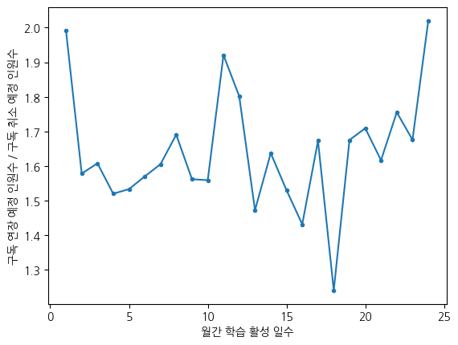

```python
dffd = pd.DataFrame(grouped.T.iloc[0,:] /grouped.T.iloc[1,:],)
plt.xlabel('월간 학습 활성 일수')
plt.ylabel('구독 연장 예정 인원수 / 구독 취소 예정 인원수')
plt.plot(dffd,marker = '.')
```

### 결론

- 구독을 연장하는 사람과 구독을 중단하는 사람들 사이에는 큰 차이가 존재하지 않음